# dplyr_Rick_Schneider

Rick SCHNEIDER

3 november 2018

Please, submit your work in shape of a zipped folder containing an RStudio project to xhec2018@thinkr.fr

Deadline : 4th november, 11:00 PM

The name of the project should be âdplyr_firstname_lastnameâ.

The project must contain a .Rmd file and the corresponding rendered .html file. Packages should be loaded at the top of the .Rmd file.

## Warm-up

### Make sure you’ve installed {dplyr} >= 0.7 and {prenoms} package

### Load here `{dplyr}`, `{prenoms}` and any other needed package

```r
#load packages:
library(dplyr)
library(prenoms)
library(tidyverse)
library(readxl)
library(tidyr)
library(knitr)
library(sf)
```

### Import

#### prenomsdataset

Using `data(prenoms)` load `prenoms` dataset from `{prenoms}` package.

```r
#load data
data(prenoms)
```

What kind of object is `prenoms` ?

```r
class(prenoms)
```

```
## [1] "tbl_df"     "tbl"        "data.frame"
```

Explore the database using the ‘5-functions-to-always-run-on-a-database’

```r
head(prenoms)
dim(prenoms)
names(prenoms)
summary(prenoms)
#View(prenoms)
```

Using `glimpse`, have a look at `prenoms`’s structure.

```r
glimpse(prenoms)
```

```
## Observations: 3,712,763
## Variables: 6
## $ year <int> 1900, 1900, 1900, 1900, 1900, 1900, 1900, 1900, 1900, 190...
## $ sex  <chr> "F", "F", "F", "F", "F", "F", "F", "F", "F", "F", "F", "F...
## $ name <chr> "Adèle", "Adrienne", "Aimée", "Alice", "Alphonsine", "Amé...
## $ n    <int> 5, 9, 7, 24, 5, 8, 5, 6, 21, 12, 21, 6, 5, 5, 17, 3, 5, 1...
## $ dpt  <chr> "01", "01", "01", "01", "01", "01", "01", "01", "01", "01...
## $ prop <dbl> 0.0015777848, 0.0028400126, 0.0022088987, 0.0075733670, 0...
```

#### Regions, departements and surfaces

Load the “dpt_data_modif.csv” dataset from IGN (French public state administrative establishment founded in 1940[1] to produce and maintain geographical information for France and its overseas departments and territories) using the appropriate function. Data have been prepared for you: the surface of departement has been calculated and spatial data removed.

```r
dpt_data_modif = read_csv("data/dpt_data_modif.csv")
```

#### Elementary and college schools

We also fetched for you on [data.gouv.fr](https://www.data.gouv.fr/fr/datasets/adresse-et-geolocalisation-des-etablissements-denseignement-du-premier-et-second-degres/#_) the addresses of “primary and secondary schools, the administrative structures of the Ministry of National Education. Public and private sectors.”

1. Data preprocessing
   - Import the csv file : “DEPP-etab-1D2D.csv” and name it “depp_orig”
     - Encoding is `"latin1"`
   - Transform zip code (“code_postal_uai”) into 5 characters with zeros
   - Extract department numbers (“dpt”) starting from column “code_postal_uai”
   - Save the modifications into “depp_modif.csv”

```r
depp_orig <- read.delim("data/Depp-etab-1D2D.csv", header = T,";",encoding = "latin1")

#"code_postal_uai" is an int; we need to transform it to a char of 5 char an fill up with 0's
depp_orig$code_postal_uai <- parse_character(depp_orig$code_postal_uai)
depp_orig$code_postal_uai <- str_pad(depp_orig$code_postal_uai, 5, pad = "0", "left")

depp_orig$dpt <- str_sub(depp_orig$code_postal_uai, start = 1, end = 2)


write.csv2(depp_orig, file = "data/depp_modif2.csv")
```

2. Read the pre-processed “depp_modif.csv” file

```r
depp_modif <- read_csv2("data/depp_modif2.csv", locale = locale(encoding = "latin1"))
#remove first column:
depp_modif <- depp_modif[,-1]
```

#### Facts observed by the police services and national gendarmerie units by department

We also gathered data from [data.gouv.fr](https://www.data.gouv.fr/fr/datasets/faits-constates-par-index-par-departement-et-par-annee/#_) concerning “all the facts observed by the police services and national gendarmerie units by department from 1996 to 2011”

1. Data preprocessing
   - Import Excel sheet “2010” from “faitsconstatespardepartementde2002-a-2011.xls” file
     - *beware of the original formatting*
   - Copy it into “faits_2010_modif” in order to make some modifications:
     - Delete Excel calculations:
       - `Tout_dÃ©partement`, `Tout_index`
     - Transform in long format using `gather`
       - 4 columns : Index, LibellÃ©, dpt, nombre
     - save the dataframe into a csv file “faits_2010_modif.csv”

```r
faits_2010 = read_excel("data/faitsconstatespardepartementde2002-a-2011.xls", sheet = "2010")

#change the column names to the names that are currently stored in the second row
colnames(faits_2010) = faits_2010[2, ]

#delte row 1 to 3, as they are not needed anymore.
#row 1 is empty, row 2 contains the titles so it is no longer needed and row 3 contains the excel computation "Tout_Index""
faits_2010=faits_2010[-(1:3), ,drop=FALSE]

#Now we need to delete the column containing the excel computation "Tout_Departement"
faits_2010 <- faits_2010 %>%
                select(-"Tout département")

#gather
faits_2010 <- gather(faits_2010,"dpt","nombre",3:98)

#delete column "Service ÃÂ  comp?tence national"
faits_2010 <- faits_2010 %>%
                select(-"Service à compétence national")

write.csv(faits_2010, file = "data/faits_2010_modif2.csv")
```

2. Read preprocessed file “faits_2010_modif.csv”

```r
#Load file:
faits_2010_modif=read_csv("data/faits_2010_modif2.csv", locale = locale(encoding = "latin1"))
#remove first column:
faits_2010_modif <- faits_2010_modif[,-1]
```

## Analyses

Some assumptions to do the exercise:

- every child born in a department stays into that department until the end of college
- every children between 11 and 14 years old is in a college
- the number of college is constant between 2010 and 2016
- College “ÃÂ ouvrir” (i.e. “to be open”) do not have children. Others have.

### Filter datasets to Metropolitan France

Datasets to be filtered: `prenoms`, `depp_modif`, `faits_2010_modif`, `dpt_data_modif`

- Department named “2A” and “2B” should be merged to “20”
- We only work with data in Metropolitan France, which means for “dpt” between `01` and `95` included. Others needs to be filtered.

```r
#save a copys:
prenoms_c <- prenoms
dpp_modif_c <- depp_modif
faits_2010_modif_c <- faits_2010_modif
dpt_data_modif_c <- dpt_data_modif


#only dpt 01 to 95
prenoms_c <- prenoms_c %>%
                filter(!dpt %in%  c("96","97","98","99","100","971","972","973","974"))
#dpp_modif_c ha NA values for code postal. My assumption is that thoses are still under construction. As a result, we are not going to include them in our model!
#list of 01 ... 99
c <- (1:95)
c <- sprintf("%02d",c)
dpp_modif_c <- dpp_modif_c %>%
                filter(dpt %in%  c)
faits_2010_modif_c <- faits_2010_modif_c %>%
                filter(!dpt %in%  c("96","97","98","99","100","971","972","973","974"))

sum(is.na(dpp_modif_c$code_postal_uai))
```

```
## [1] 0
```

```r
#####  Prenoms  #####
#1) Correct the column n. If 2 people from 2A and 2B have the same year, name and sex, we need to update n
col_AB <- prenoms_c %>%
            filter(dpt %in% c("2A","2B")) %>%
            group_by(year,name,sex) %>%
            mutate(n=sum(n)) %>%                   #identical entries in 2A,2B -> sum of n
            ungroup()
#2) Update the proportion which has and change the name of dpt to "20. Delete the duplicate rows
col_AB <- col_AB %>%
            group_by(year,sex) %>%
            mutate(prop=n/sum(n),                  #calculate the new proportions
                   dpt="20") %>%                   #replace 2a and 2B by 20
            ungroup() %>%
            distinct()


#3) Merge the new rows in col_AB withe the rows in prenoms_c (replace the rows containing 2A and 2B)
#Get rid of 2A and 2B in prenoms_c
prenoms_c <- prenoms_c %>%
                filter(!dpt %in% c("2A","2B"))
#merge them together:
prenoms_c <- rbind(prenoms_c,col_AB)

#with the levels funtion we can see that we sucessfully removed 2A,2B and created dpt 20
levels(as.factor(prenoms_c$dpt))
```

```
##  [1] "01" "02" "03" "04" "05" "06" "07" "08" "09" "10" "11" "12" "13" "14"
## [15] "15" "16" "17" "18" "19" "20" "21" "22" "23" "24" "25" "26" "27" "28"
## [29] "29" "30" "31" "32" "33" "34" "35" "36" "37" "38" "39" "40" "41" "42"
## [43] "43" "44" "45" "46" "47" "48" "49" "50" "51" "52" "53" "54" "55" "56"
## [57] "57" "58" "59" "60" "61" "62" "63" "64" "65" "66" "67" "68" "69" "70"
## [71] "71" "72" "73" "74" "75" "76" "77" "78" "79" "80" "81" "82" "83" "84"
## [85] "85" "86" "87" "88" "89" "90" "91" "92" "93" "94" "95"
```

```r
#####  dpp_modif  #####
dpp_modif_c  %>%
    filter(dpt %in% c("2A","2B")) %>%
    summarise(n())                      #result:0, no wos with 2A,2B
```

```
## # A tibble: 1 x 1
##   `n()`
##   <int>
## 1     0
```

```r
levels(as.factor(dpp_modif_c$dpt))
```

```
##  [1] "01" "02" "03" "04" "05" "06" "07" "08" "09" "10" "11" "12" "13" "14"
## [15] "15" "16" "17" "18" "19" "20" "21" "22" "23" "24" "25" "26" "27" "28"
## [29] "29" "30" "31" "32" "33" "34" "35" "36" "37" "38" "39" "40" "41" "42"
## [43] "43" "44" "45" "46" "47" "48" "49" "50" "51" "52" "53" "54" "55" "56"
## [57] "57" "58" "59" "60" "61" "62" "63" "64" "65" "66" "67" "68" "69" "70"
## [71] "71" "72" "73" "74" "75" "76" "77" "78" "79" "80" "81" "82" "83" "84"
## [85] "85" "86" "87" "88" "89" "90" "91" "92" "93" "94" "95"
```

```r
dim(dpp_modif_c)
```

```
## [1] 63805    18
```

```r
#####  faits_2010_modif  #####
faits_2010_modif_c  %>%
    filter(dpt %in% c("2A","2B")) %>%
    summarise(n())                       #result = 206, we need t change them!
```

```
## # A tibble: 1 x 1
##   `n()`
##   <int>
## 1   206
```

```r
col_AB <- faits_2010_modif_c %>%
            filter(dpt %in% c("2A","2B")) %>%
            group_by(Libellé) %>%
            mutate(nombre=sum(nombre)) %>%
            ungroup() %>%
            mutate(dpt="20") %>%
            ungroup() %>%
            distinct()

faits_2010_modif_c <- faits_2010_modif_c %>%
                         filter(!dpt %in% c("2A","2B"))

faits_2010_modif_c <- rbind(faits_2010_modif_c,col_AB)

####  dpt_data_modif_c  ####
#For now, we are not going to change 2A and 2B into 20, as this file contains information about 2A and 2B that we cannot summarize in one row without more information available. In a later step, if we need to do computations with the surface, we can simply add up the surface of 2A and 2B.
```

### National average number of children per college in 2010 ?

```r
### ASSUMPTIONS: ###
# every children between 11 and 14 years old is in a college
# the number of college is constant between 2010 and 2016
# College "ÃÂ  ouvrir" (i.e. "to be open") do not have children. Others have.


#number of children between 11 and 14 years (born in 1996-1999 inclusive(assumption))
n_child_11_14 <- prenoms_c %>%
                    filter(year %in% 1996:1999) %>%
                    summarise(sum(n))
#number of colleges in 2010:
n_college_2010 <- dpp_modif_c %>%
                    filter(nature_uai %in% c(352,350,340)) %>%    ###A ourvir???????
                    summarise(n())
n_child_11_14
```

```
## # A tibble: 1 x 1
##   `sum(n)`
##      <int>
## 1  2409414
```

```r
n_college_2010
```

```
## # A tibble: 1 x 1
##   `n()`
##   <int>
## 1  6915
```

```r
#calculate average:
average=n_child_11_14/n_college_2010
average
```

```
##    sum(n)
## 1 348.433
```

### Average number of children per college in 2010 in each department?

- Arrange departments according to the calculated average in descending order

```r
#number of children between 11 and 14 years (born in 1996-1999 inclusive(assumption)) per department
n_child_11_14_dp <- prenoms_c %>%
                    filter(year %in% 1996:1999) %>%
                    group_by(dpt) %>%
                    arrange(dpt) %>%
                    summarise(sum_child=sum(n))

dim(n_child_11_14_dp) #95 rows -> dpt =1 to dpt= 95
```

```
## [1] 95  2
```

```r
#number of colleges in 2010 per departments
n_college_2010_dp <- dpp_modif_c %>%
                        filter(nature_uai %in% c(352,350,340)) %>% ###A ourvir???????
                        group_by(dpt) %>%
                        arrange(dpt) %>%
                        summarise(count_coll=n())

dim(n_college_2010_dp) #96 rows -->one row contains NA, i.e. 9840422L has null entries!
```

```
## [1] 95  2
```

```r
n_college_2010_dp <- n_college_2010_dp %>% drop_na() #remove the NAs
dim(n_college_2010_dp) #95 rows as well now
```

```
## [1] 95  2
```

```r
#Calculate averae per dpt, sort in decreasing order and rename column to avg_child_per_dpt
average_dpt <- n_child_11_14_dp
average_dpt$sum_child <- n_child_11_14_dp$sum_child/n_college_2010_dp$count_coll
average_dpt <- average_dpt %>%
                  arrange(desc(sum_child)) %>%
                  rename(avg_child_per_dpt = sum_child)
```

### Number of Facts observed by the police services in 2010 per department ?

```r
#group by departments and sum the # of facts:
n_facts_per_dpt <- faits_2010_modif_c %>%
                      group_by(dpt) %>%
                      summarise(sum_facts=sum(nombre))

#delete he last row (service Ã  compÃ©tence nationale), which is not a dpt per definition
n_facts_per_dpt <- n_facts_per_dpt[-96,]
```

### Number of children born, number of colleges and facts related by the police services per department in 2010 ?

- Group all information in the same table
- Arrange by descending order of children, schools and facts

```r
# n_facts_per_dpt : facts related by the police services per department in 2010
# n_college_2010_dp : number of colleges in 2010 per dpt

# n_child_2010_dp: number of children born per dpt in 2010
n_child_2010_dp <- prenoms_c %>%
                    filter(year == 2010) %>%
                    group_by(dpt) %>%
                    arrange(dpt) %>%
                    summarise(sum_child=sum(n))

#join the tables:
table_dpt_2010 <- inner_join(n_child_2010_dp, n_college_2010_dp, by = "dpt")
table_dpt_2010 <- inner_join(table_dpt_2010,n_facts_per_dpt, by = "dpt")

#arrang in descending order:
table_dpt_2010 <- table_dpt_2010 %>% arrange(desc(sum_child),desc(count_coll),desc(sum_facts))
```

### Number of children born, number of colleges and facts related by the police services per kmÂ² in 2010 by department?

```r
#square_km per dpt:
km2_dpt <- dpt_data_modif_c %>%
              select(CODE_DEPT,surface_m) %>%
              mutate(surface_m = surface_m/(10^6))

#Change 2A and 2B to 20:
#sum of m's for 2A and 2B:
sum_20 <- km2_dpt %>%
            filter(CODE_DEPT %in% c("2A","2B")) %>%
            summarise(sum(surface_m))
km2_dpt$CODE_DEPT <- as.character(km2_dpt$CODE_DEPT)
km2_dpt[km2_dpt$CODE_DEPT=="2A",1] <- "20"
km2_dpt[km2_dpt$CODE_DEPT=="2A",2] <- sum_20
km2_dpt <- km2_dpt[!km2_dpt$CODE_DEPT == "2B",]
km2_dpt[km2_dpt$CODE_DEPT=="20",2]=km2_dpt[km2_dpt$CODE_DEPT=="20",2]*2

#rename CODE_DEPT to dpt:
km2_dpt <- km2_dpt %>%
              arrange(CODE_DEPT) %>%
              rename(dpt = CODE_DEPT)
#save a copy for last question:
km2_dpt_c <- km2_dpt


#join the 2 tables together to have every information in 1 table
km2_dpt <- inner_join(km2_dpt,table_dpt_2010,by="dpt")


#calculate the rates
km2_dpt <- km2_dpt %>%
            mutate(sum_child=sum_child/surface_m,
                   count_coll=count_coll/surface_m,
                   sum_facts=sum_facts/surface_m) %>%
            rename(child_2010_per_km2 = sum_child,
                   coll_2010_per_km2 = count_coll,
                   facts_2010_per_km2 = sum_facts) %>%
            select(-surface_m) %>%
            arrange(dpt)
```

### Is there a correlation between the number of birth and the number of facts related by the police per kmÂ² in 2010 ?

```r
cor(km2_dpt$child_2010_per_km2,km2_dpt$facts_2010_per_km2)
```

```
## [1] 0.9909816
```

```r
#strong positive correlation! cor=0.991. The higher the number of births in one year, the higher the facts related by the police per km2 in 2010. Linear relationship!
```

### What is the mean regional density (in number/kmÂ²) of the 15 most given first names in France ?

- Filter the 15 most given first names in France
- Create a wide table with the department as observations and the 15 most given names in columns (as variables): the count is at the row-column intersection
- merge with the surface department infos
- Compute the region surface and the sum of names by region

```r
#Assumption: we only work with data in Metropolitan France, which means for "dpt" between `01` and `95` included


#filter the 15 most given first names:
names_top15 <- prenoms_c %>%
                  group_by(name) %>%
                  summarise(popularity=sum(n)) %>%
                  arrange(desc(popularity)) %>%
                  top_n(15) %>%
                  select(name) %>%
                  as_vector()
#wide table:
wtable <- prenoms_c %>%
              select(-year,-sex,-prop) %>%
              group_by(dpt,name) %>%
              filter(name %in% names_top15) %>%
              mutate(n = sum(n)) %>%
              distinct()

#add the surface:
wtable <- wtable %>%
            spread(key = name, value = n) %>%
            full_join(km2_dpt_c, id = "dpt")

#join
reg <- dpt_data_modif_c %>%
          rename(dpt=CODE_DEPT) %>%
          select(NOM_REG,dpt) %>%
          filter(!dpt %in% c("2A","2B"))

wtable <- wtable %>%
            full_join(reg, id = "dpt")

#change missing name:
wtable[20,"NOM_REG"] <- "CORSE"

#delete dpt column:
wtable <- wtable[,-1]


## second part: Compute the region surface and the sum of names by region ##

wtable2 <- aggregate(wtable[,1:16],by=wtable[,17],sum)

#What is the mean regional density (in number/kmÃÂ²) of the 15 most given first names in France?
wtable2[,2:16] = wtable2[,2:16]/wtable2[,17]
```

#### Bonus question : map the mean regional density (in number/kmÂ²) of the 15 most given first names in France

- Use the “department” shapefile to cross information and map data

```r
#read in:
map <- st_read("data/departements/DEPARTEMENT.shp")
map_join <- inner_join(wtable2,map,by="NOM_REG")
names_top15
```

```
##      name1      name2      name3      name4      name5      name6
##    "Marie"     "Jean"   "Pierre"   "Michel"    "André"   "Jeanne"
##      name7      name8      name9     name10     name11     name12
## "Philippe"     "René"    "Louis"    "Alain"  "Jacques"  "Bernard"
##     name13     name14     name15
##   "Marcel"   "Claude"   "Daniel"
```

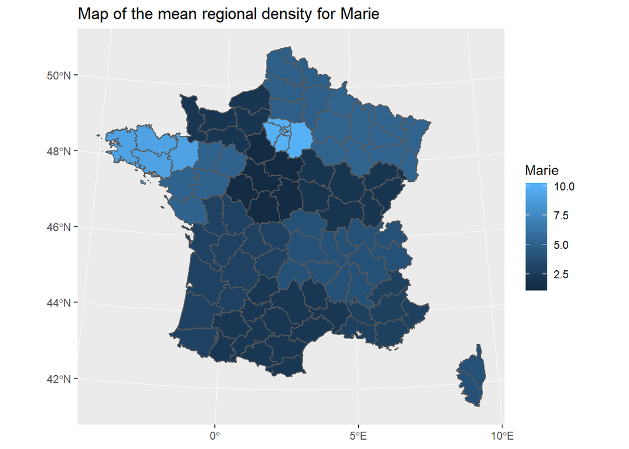

```r
#plot 15 different maps for the mean regional densities:
ggplot(map_join)+
            geom_sf(aes_string(fill=names_top15[1])) +
            coord_sf(crs = st_crs(map)) +
            labs(title="Map of the mean regional density for Marie")
```

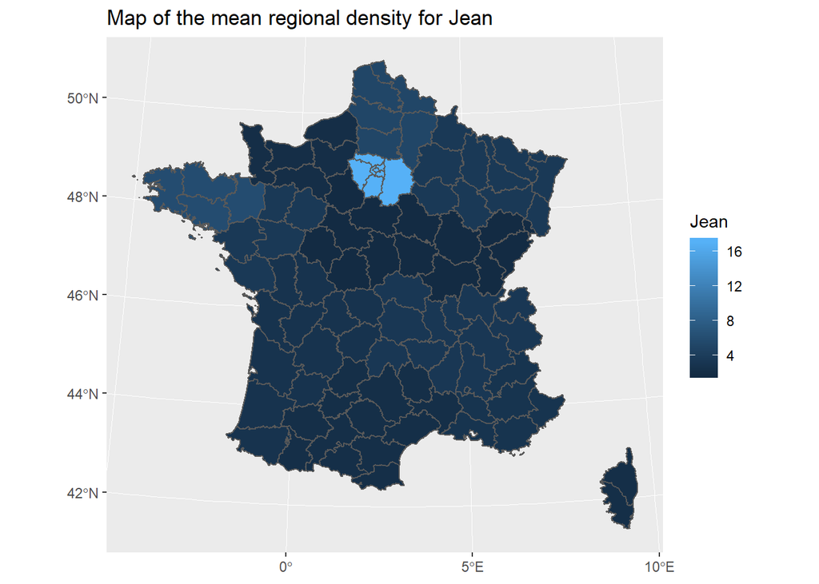

```r
ggplot(map_join)+
            geom_sf(aes(fill=Jean)) +
            coord_sf(crs = st_crs(map)) +
            labs(title="Map of the mean regional density for Jean")
```

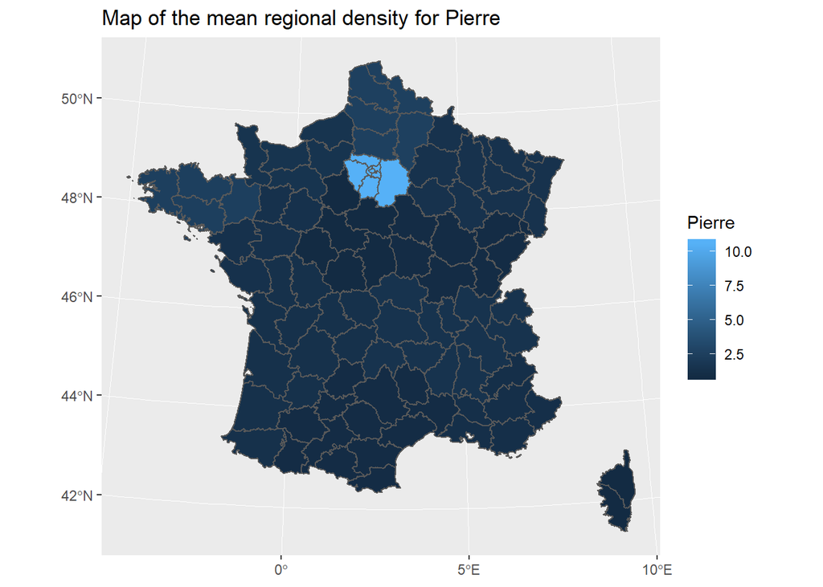

```r
ggplot(map_join)+
            geom_sf(aes_string(fill="Pierre")) +
            coord_sf(crs = st_crs(map)) +
            labs(title="Map of the mean regional density for Pierre")
```

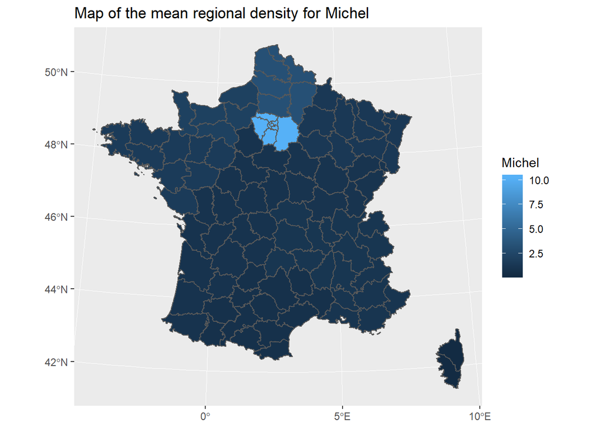

```r
ggplot(map_join)+
            geom_sf(aes_string(fill=names_top15[4])) +
            coord_sf(crs = st_crs(map)) +
            labs(title="Map of the mean regional density for Michel")
```

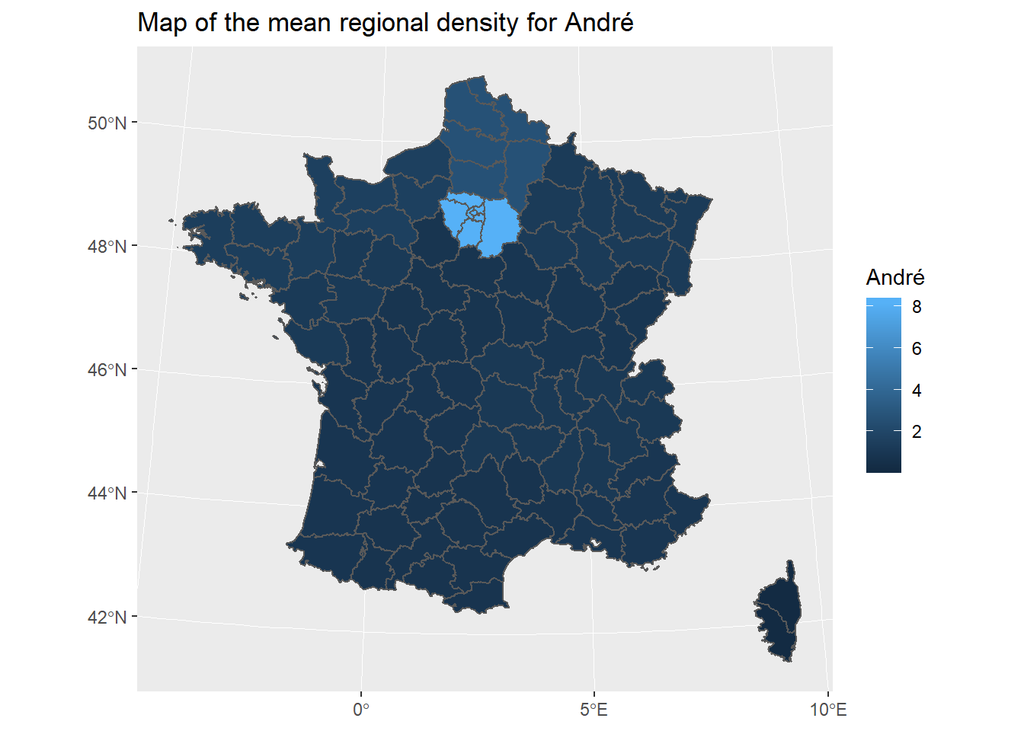

```r
ggplot(map_join)+
            geom_sf(aes_string(fill=names_top15[5])) +
            coord_sf(crs = st_crs(map)) +
            labs(title="Map of the mean regional density for André")
```

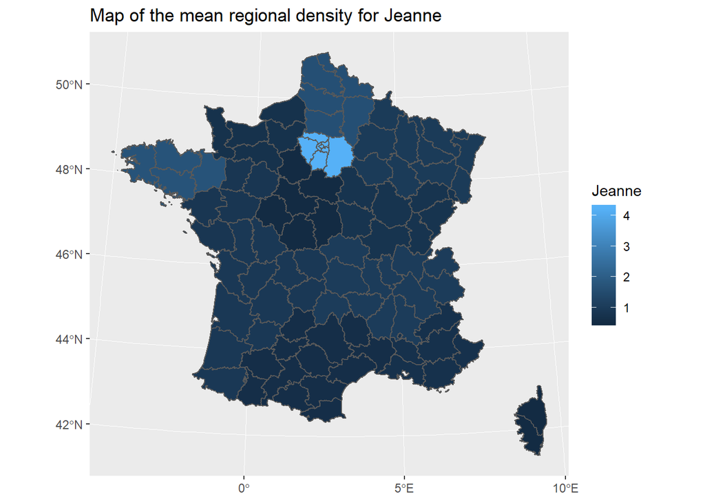

```r
ggplot(map_join)+
            geom_sf(aes_string(fill=names_top15[6])) +
            coord_sf(crs = st_crs(map)) +
            labs(title="Map of the mean regional density for Jeanne")
```

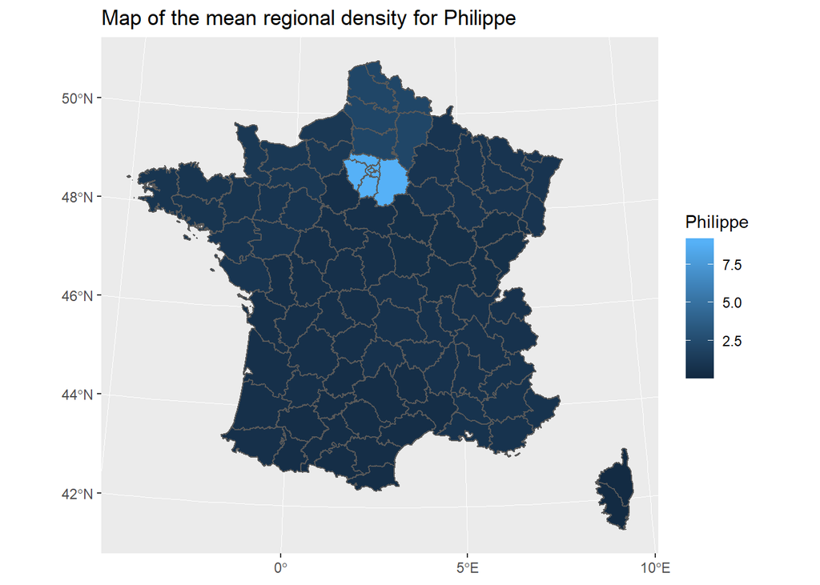

```r
ggplot(map_join)+
            geom_sf(aes_string(fill=names_top15[7])) +
            coord_sf(crs = st_crs(map)) +
            labs(title="Map of the mean regional density for Philippe")
```

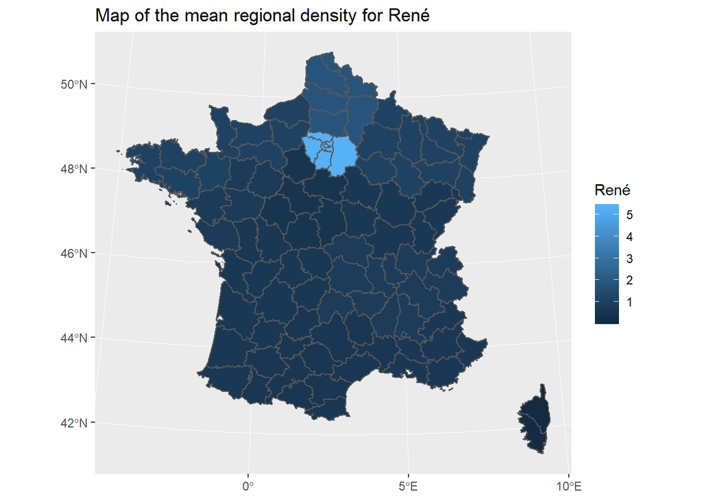

```r
ggplot(map_join)+
            geom_sf(aes_string(fill=names_top15[8])) +
            coord_sf(crs = st_crs(map)) +
            labs(title="Map of the mean regional density for René")
```

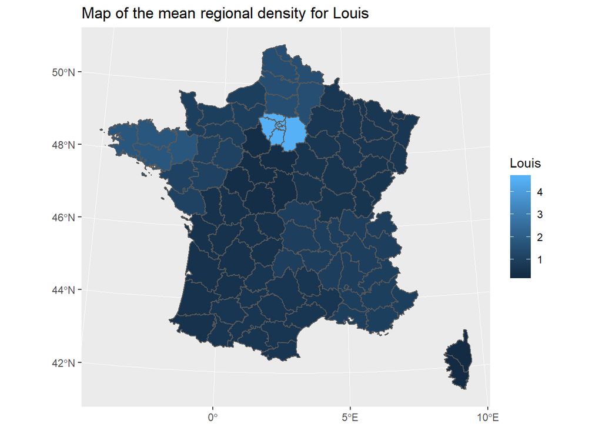

```r
ggplot(map_join)+
            geom_sf(aes_string(fill=names_top15[9])) +
            coord_sf(crs = st_crs(map)) +
            labs(title="Map of the mean regional density for Louis")
```

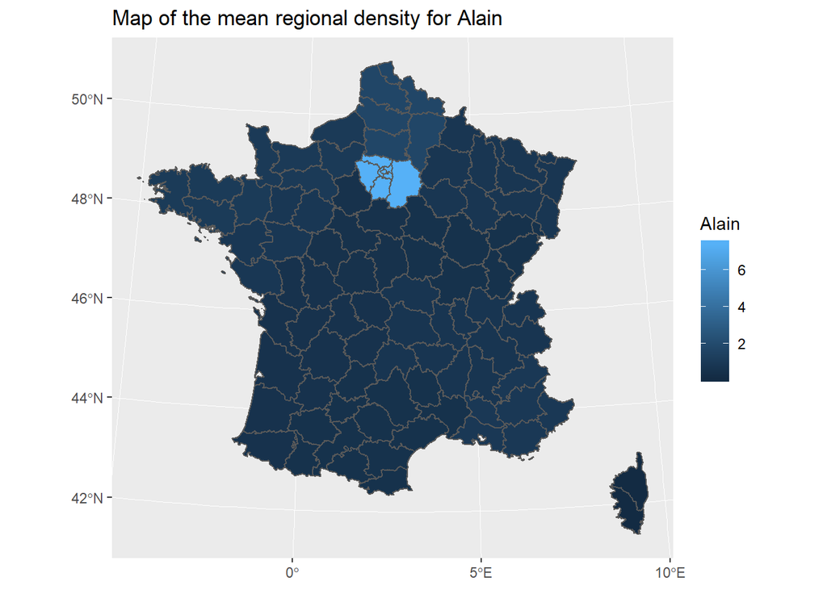

```r
ggplot(map_join)+
            geom_sf(aes_string(fill=names_top15[10])) +
            coord_sf(crs = st_crs(map)) +
            labs(title="Map of the mean regional density for Alain")
```

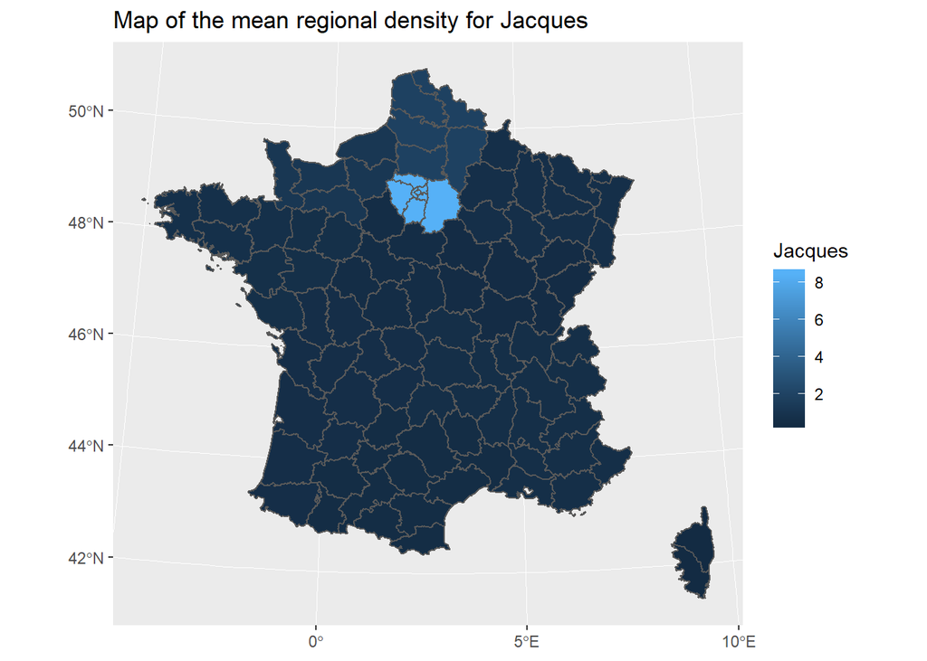

```r
ggplot(map_join)+
            geom_sf(aes_string(fill=names_top15[11])) +
            coord_sf(crs = st_crs(map)) +
            labs(title="Map of the mean regional density for Jacques")
```

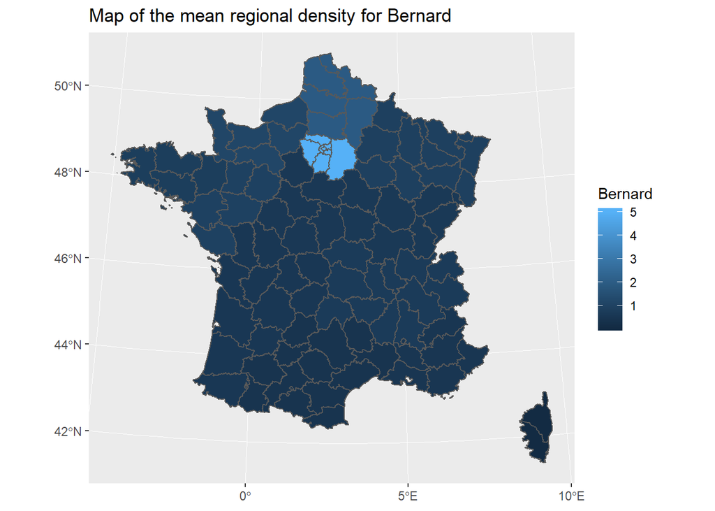

```r
ggplot(map_join)+
            geom_sf(aes_string(fill=names_top15[12])) +
            coord_sf(crs = st_crs(map)) +
            labs(title="Map of the mean regional density for Bernard")
```

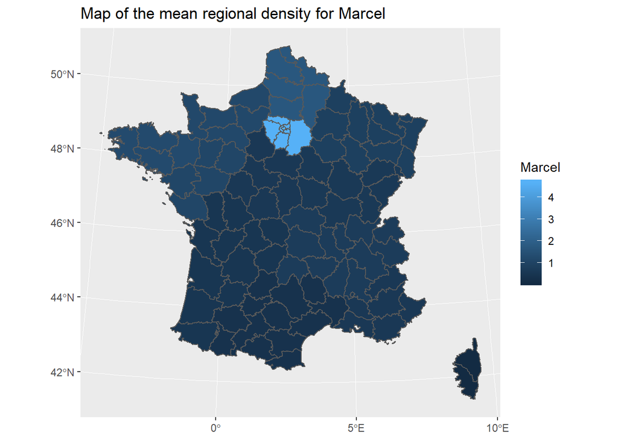

```r
ggplot(map_join)+
            geom_sf(aes_string(fill=names_top15[13])) +
            coord_sf(crs = st_crs(map)) +
            labs(title="Map of the mean regional density for Marcel")
```

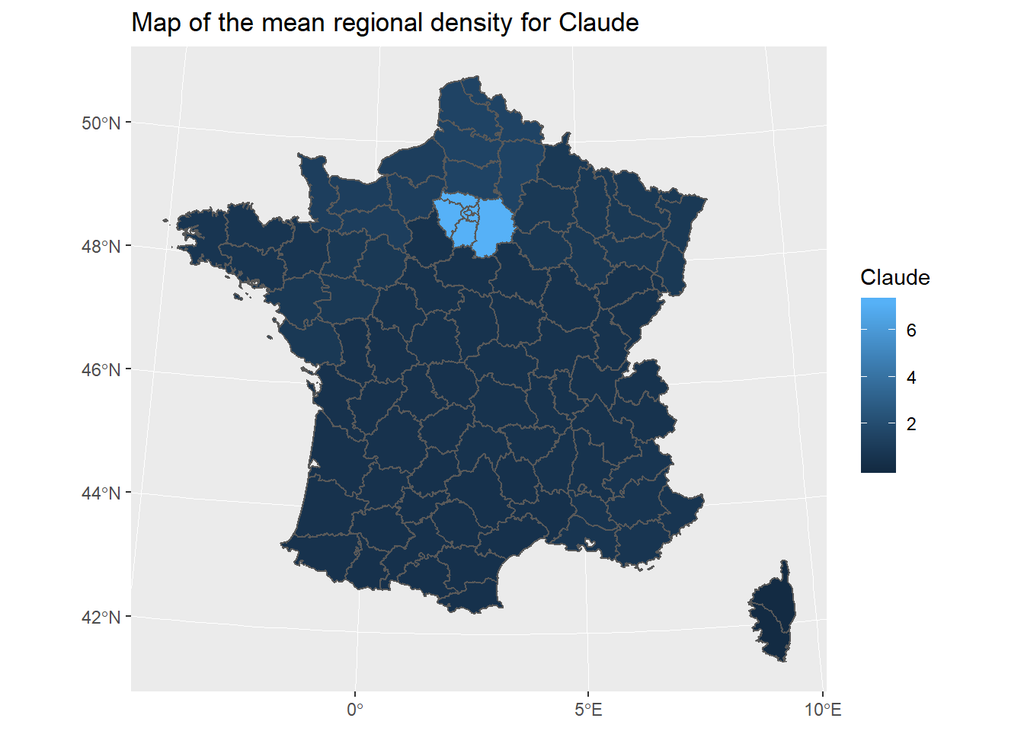

```r
ggplot(map_join)+
            geom_sf(aes_string(fill=names_top15[14])) +
            coord_sf(crs = st_crs(map)) +
            labs(title="Map of the mean regional density for Claude")
```

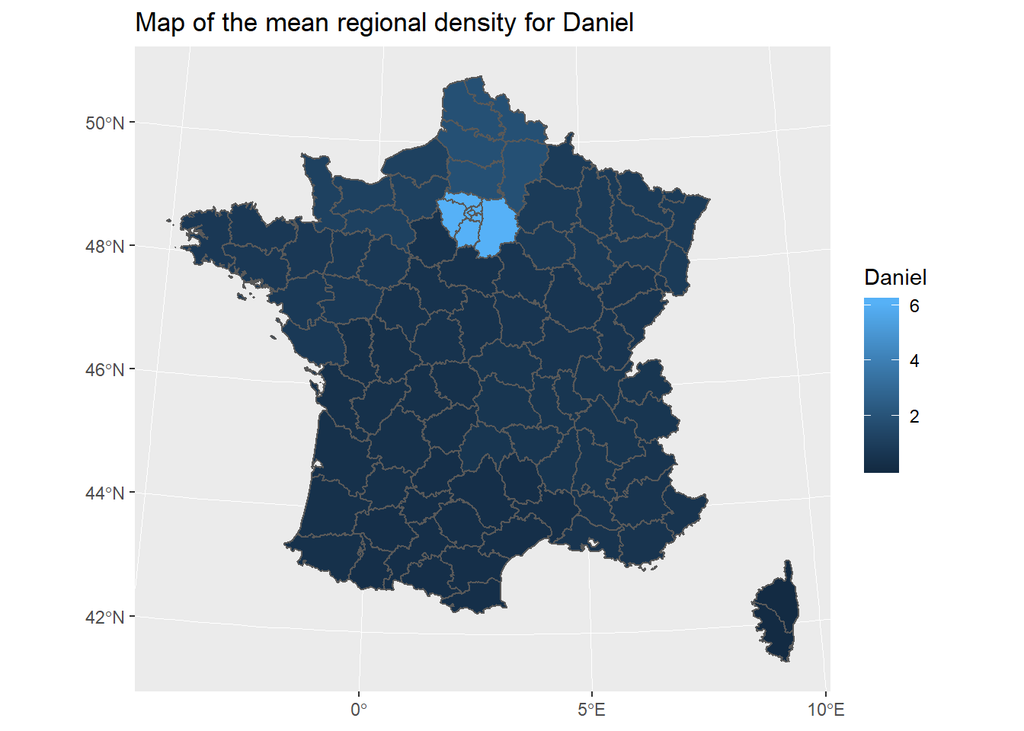

```r
ggplot(map_join)+
            geom_sf(aes_string(fill=names_top15[15])) +
            coord_sf(crs = st_crs(map)) +
            labs(title="Map of the mean regional density for Daniel")
```